# Optimal Treatment Analysis

## Outcome Variable

**Outcome Variable:** haz

## Predictor Variables

**Intervention Variable:** impsan

**Adjustment Set:**

- arm
- sex
- W_mage
- meducyrs
- feducyrs
- hhwealth_quart
- hfoodsec
- W_mhtcm
- W_nrooms
- W_nchldlt5
- W_parity
- impfloor
- safeh20
- delta_W_mage
- delta_meducyrs
- delta_feducyrs
- delta_hhwealth_quart
- delta_hfoodsec
- delta_W_mhtcm
- delta_W_nrooms
- delta_W_nchldlt5
- delta_W_parity
- delta_impfloor
- delta_safeh20

## Stratifying Variables

The analysis was stratified on these variable(s):

- agecat
- studyid
- country

## Data Summary

| agecat | studyid | country | impsan | n_cell | n |
| --- | --- | --- | --- | --- | --- |
| Birth | ki0047075b-MAL-ED | BANGLADESH | 1 | 197 | 234 |
| Birth | ki0047075b-MAL-ED | BANGLADESH | 0 | 37 | 234 |
| Birth | ki0047075b-MAL-ED | BRAZIL | 1 | 170 | 174 |
| Birth | ki0047075b-MAL-ED | BRAZIL | 0 | 4 | 174 |
| Birth | ki0047075b-MAL-ED | INDIA | 1 | 92 | 190 |
| Birth | ki0047075b-MAL-ED | INDIA | 0 | 98 | 190 |
| Birth | ki0047075b-MAL-ED | NEPAL | 1 | 170 | 171 |
| Birth | ki0047075b-MAL-ED | NEPAL | 0 | 1 | 171 |
| Birth | ki0047075b-MAL-ED | PERU | 1 | 62 | 250 |
| Birth | ki0047075b-MAL-ED | PERU | 0 | 188 | 250 |
| Birth | ki0047075b-MAL-ED | SOUTH AFRICA | 1 | 2 | 213 |
| Birth | ki0047075b-MAL-ED | SOUTH AFRICA | 0 | 211 | 213 |
| Birth | ki0047075b-MAL-ED | TANZANIA, UNITED REPUBLIC OF | 1 | 0 | 113 |
| Birth | ki0047075b-MAL-ED | TANZANIA, UNITED REPUBLIC OF | 0 | 113 | 113 |
| Birth | ki1017093-NIH-Birth | BANGLADESH | 1 | 9 | 28 |
| Birth | ki1017093-NIH-Birth | BANGLADESH | 0 | 19 | 28 |
| Birth | ki1017093c-NIH-Crypto | BANGLADESH | 1 | 25 | 27 |
| Birth | ki1017093c-NIH-Crypto | BANGLADESH | 0 | 2 | 27 |
| Birth | ki1114097-CONTENT | PERU | 1 | 1 | 2 |
| Birth | ki1114097-CONTENT | PERU | 0 | 1 | 2 |
| Birth | ki1135781-COHORTS | GUATEMALA | 1 | 45 | 491 |
| Birth | ki1135781-COHORTS | GUATEMALA | 0 | 446 | 491 |
| Birth | ki1135781-COHORTS | INDIA | 1 | 1767 | 4776 |
| Birth | ki1135781-COHORTS | INDIA | 0 | 3009 | 4776 |
| Birth | ki1135781-COHORTS | PHILIPPINES | 1 | 178 | 1191 |
| Birth | ki1135781-COHORTS | PHILIPPINES | 0 | 1013 | 1191 |
| Birth | kiGH5241-JiVitA-3 | BANGLADESH | 1 | 13187 | 19592 |
| Birth | kiGH5241-JiVitA-3 | BANGLADESH | 0 | 6405 | 19592 |
| Birth | kiGH5241-JiVitA-4 | BANGLADESH | 1 | 606 | 822 |
| Birth | kiGH5241-JiVitA-4 | BANGLADESH | 0 | 216 | 822 |

[output cut: 68 more lines]

The following strata were considered:

- agecat: 24 months, studyid: ki0047075b-MAL-ED, country: BANGLADESH
- agecat: 24 months, studyid: ki0047075b-MAL-ED, country: BRAZIL
- agecat: 24 months, studyid: ki0047075b-MAL-ED, country: INDIA
- agecat: 24 months, studyid: ki0047075b-MAL-ED, country: NEPAL
- agecat: 24 months, studyid: ki0047075b-MAL-ED, country: PERU
- agecat: 24 months, studyid: ki0047075b-MAL-ED, country: SOUTH AFRICA
- agecat: 24 months, studyid: ki0047075b-MAL-ED, country: TANZANIA, UNITED REPUBLIC OF
- agecat: 24 months, studyid: ki1017093-NIH-Birth, country: BANGLADESH
- agecat: 24 months, studyid: ki1017093b-PROVIDE, country: BANGLADESH
- agecat: 24 months, studyid: ki1017093c-NIH-Crypto, country: BANGLADESH
- agecat: 24 months, studyid: ki1114097-CONTENT, country: PERU
- agecat: 24 months, studyid: ki1135781-COHORTS, country: GUATEMALA
- agecat: 24 months, studyid: ki1135781-COHORTS, country: INDIA
- agecat: 24 months, studyid: ki1135781-COHORTS, country: PHILIPPINES
- agecat: 24 months, studyid: ki1148112-LCNI-5, country: MALAWI
- agecat: 24 months, studyid: kiGH5241-JiVitA-3, country: BANGLADESH
- agecat: 24 months, studyid: kiGH5241-JiVitA-4, country: BANGLADESH
- agecat: 6 months, studyid: ki0047075b-MAL-ED, country: BANGLADESH
- agecat: 6 months, studyid: ki0047075b-MAL-ED, country: BRAZIL
- agecat: 6 months, studyid: ki0047075b-MAL-ED, country: INDIA
- agecat: 6 months, studyid: ki0047075b-MAL-ED, country: NEPAL
- agecat: 6 months, studyid: ki0047075b-MAL-ED, country: PERU
- agecat: 6 months, studyid: ki0047075b-MAL-ED, country: SOUTH AFRICA
- agecat: 6 months, studyid: ki0047075b-MAL-ED, country: TANZANIA, UNITED REPUBLIC OF
- agecat: 6 months, studyid: ki1017093-NIH-Birth, country: BANGLADESH
- agecat: 6 months, studyid: ki1017093b-PROVIDE, country: BANGLADESH
- agecat: 6 months, studyid: ki1017093c-NIH-Crypto, country: BANGLADESH
- agecat: 6 months, studyid: ki1114097-CONTENT, country: PERU
- agecat: 6 months, studyid: ki1135781-COHORTS, country: GUATEMALA
- agecat: 6 months, studyid: ki1135781-COHORTS, country: INDIA
- agecat: 6 months, studyid: ki1135781-COHORTS, country: PHILIPPINES
- agecat: 6 months, studyid: ki1148112-LCNI-5, country: MALAWI
- agecat: 6 months, studyid: kiGH5241-JiVitA-3, country: BANGLADESH
- agecat: 6 months, studyid: kiGH5241-JiVitA-4, country: BANGLADESH
- agecat: Birth, studyid: ki0047075b-MAL-ED, country: BANGLADESH
- agecat: Birth, studyid: ki0047075b-MAL-ED, country: BRAZIL
- agecat: Birth, studyid: ki0047075b-MAL-ED, country: INDIA
- agecat: Birth, studyid: ki0047075b-MAL-ED, country: NEPAL
- agecat: Birth, studyid: ki0047075b-MAL-ED, country: PERU
- agecat: Birth, studyid: ki0047075b-MAL-ED, country: SOUTH AFRICA
- agecat: Birth, studyid: ki0047075b-MAL-ED, country: TANZANIA, UNITED REPUBLIC OF
- agecat: Birth, studyid: ki1017093-NIH-Birth, country: BANGLADESH
- agecat: Birth, studyid: ki1017093c-NIH-Crypto, country: BANGLADESH
- agecat: Birth, studyid: ki1114097-CONTENT, country: PERU
- agecat: Birth, studyid: ki1135781-COHORTS, country: GUATEMALA
- agecat: Birth, studyid: ki1135781-COHORTS, country: INDIA
- agecat: Birth, studyid: ki1135781-COHORTS, country: PHILIPPINES
- agecat: Birth, studyid: kiGH5241-JiVitA-3, country: BANGLADESH
- agecat: Birth, studyid: kiGH5241-JiVitA-4, country: BANGLADESH

### Dropped Strata

Some strata were dropped due to rare outcomes:

- agecat: Birth, studyid: ki0047075b-MAL-ED, country: BRAZIL
- agecat: Birth, studyid: ki0047075b-MAL-ED, country: NEPAL
- agecat: Birth, studyid: ki0047075b-MAL-ED, country: SOUTH AFRICA
- agecat: Birth, studyid: ki0047075b-MAL-ED, country: TANZANIA, UNITED REPUBLIC OF
- agecat: Birth, studyid: ki1017093c-NIH-Crypto, country: BANGLADESH
- agecat: Birth, studyid: ki1114097-CONTENT, country: PERU
- agecat: 6 months, studyid: ki0047075b-MAL-ED, country: BRAZIL
- agecat: 6 months, studyid: ki0047075b-MAL-ED, country: NEPAL
- agecat: 6 months, studyid: ki0047075b-MAL-ED, country: SOUTH AFRICA
- agecat: 6 months, studyid: ki0047075b-MAL-ED, country: TANZANIA, UNITED REPUBLIC OF
- agecat: 6 months, studyid: ki1148112-LCNI-5, country: MALAWI
- agecat: 24 months, studyid: ki0047075b-MAL-ED, country: BRAZIL
- agecat: 24 months, studyid: ki0047075b-MAL-ED, country: NEPAL
- agecat: 24 months, studyid: ki0047075b-MAL-ED, country: SOUTH AFRICA
- agecat: 24 months, studyid: ki0047075b-MAL-ED, country: TANZANIA, UNITED REPUBLIC OF
- agecat: 24 months, studyid: ki1148112-LCNI-5, country: MALAWI

## Methods Detail

We’re interested in the causal parameters $E[Y_a]$ for all values of $a \in \mathcal{A}$. These parameters represent the mean outcome if, possibly contrary to fact, we intervened to set all units to have $A=a$. Under the randomization and positivity assumptions, these are identified by the statistical parameters $\psi_a=E_W[E_{Y|A,W}(Y|A=a,W)]$. In addition, we’re interested in the mean of $Y$, $E[Y]$ under no intervention (the observed mean). We will estimate these parameters by using SuperLearner to fit the relevant likelihood factors – $E_{Y|A,W}(Y|A=a,W)$ and $p(A=a|W)$, and then updating our likelihood fit using a joint TMLE.

For unadjusted analyses ($W=\{\}$), initial likelihoods were estimated using Lrnr_glm to estimate the simple $E(Y|A)$ and Lrnr_mean to estimate $p(A)$. For adjusted analyses, a small library containing Lrnr_glmnet, Lrnr_xgboost, and Lrnr_mean was used.

Having estimated these parameters, we will then use the delta method to estimate relative risks and attributable risks relative to a prespecified baseline level of $A$.

# Results Detail

## Results Plots

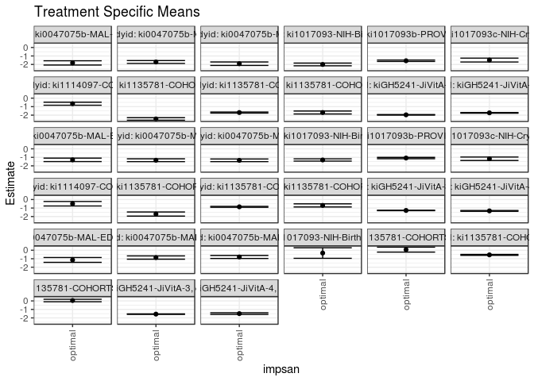

## Results Table

### Parameter: TSM

| agecat | studyid | country | intervention_level | baseline_level | estimate | ci_lower | ci_upper |
| --- | --- | --- | --- | --- | --- | --- | --- |
| Birth | ki0047075b-MAL-ED | BANGLADESH | optimal | observed | -1.1447295 | -1.4298218 | -0.8596371 |
| Birth | ki0047075b-MAL-ED | INDIA | optimal | observed | -0.8622474 | -1.0549111 | -0.6695837 |
| Birth | ki0047075b-MAL-ED | PERU | optimal | observed | -0.7910055 | -0.9697402 | -0.6122709 |
| Birth | ki1017093-NIH-Birth | BANGLADESH | optimal | observed | -0.3313504 | -0.9534248 | 0.2907239 |
| Birth | ki1135781-COHORTS | GUATEMALA | optimal | observed | 0.0720449 | -0.2214964 | 0.3655862 |
| Birth | ki1135781-COHORTS | INDIA | optimal | observed | -0.5471106 | -0.6029170 | -0.4913043 |
| Birth | ki1135781-COHORTS | PHILIPPINES | optimal | observed | 0.0450765 | -0.1013910 | 0.1915440 |
| Birth | kiGH5241-JiVitA-3 | BANGLADESH | optimal | observed | -1.5534943 | -1.5788770 | -1.5281117 |
| Birth | kiGH5241-JiVitA-4 | BANGLADESH | optimal | observed | -1.4961407 | -1.5933319 | -1.3989496 |
| 6 months | ki0047075b-MAL-ED | BANGLADESH | optimal | observed | -1.2951509 | -1.4988054 | -1.0914964 |
| 6 months | ki0047075b-MAL-ED | INDIA | optimal | observed | -1.3397787 | -1.5065938 | -1.1729637 |
| 6 months | ki0047075b-MAL-ED | PERU | optimal | observed | -1.3499215 | -1.5066636 | -1.1931795 |
| 6 months | ki1017093-NIH-Birth | BANGLADESH | optimal | observed | -1.3089286 | -1.4443908 | -1.1734663 |
| 6 months | ki1017093b-PROVIDE | BANGLADESH | optimal | observed | -1.0816868 | -1.1596637 | -1.0037100 |
| 6 months | ki1017093c-NIH-Crypto | BANGLADESH | optimal | observed | -1.1685830 | -1.3715059 | -0.9656600 |
| 6 months | ki1114097-CONTENT | PERU | optimal | observed | -0.4951009 | -0.7592217 | -0.2309800 |
| 6 months | ki1135781-COHORTS | GUATEMALA | optimal | observed | -1.7080791 | -1.9513394 | -1.4648187 |
| 6 months | ki1135781-COHORTS | INDIA | optimal | observed | -0.8577059 | -0.9115796 | -0.8038322 |
| 6 months | ki1135781-COHORTS | PHILIPPINES | optimal | observed | -0.6900992 | -0.8741314 | -0.5060670 |
| 6 months | kiGH5241-JiVitA-3 | BANGLADESH | optimal | observed | -1.2834758 | -1.3089889 | -1.2579627 |
| 6 months | kiGH5241-JiVitA-4 | BANGLADESH | optimal | observed | -1.3361769 | -1.3845628 | -1.2877910 |
| 24 months | ki0047075b-MAL-ED | BANGLADESH | optimal | observed | -1.8179041 | -2.0680062 | -1.5678020 |
| 24 months | ki0047075b-MAL-ED | INDIA | optimal | observed | -1.7083409 | -1.8759883 | -1.5406934 |
| 24 months | ki0047075b-MAL-ED | PERU | optimal | observed | -1.9097502 | -2.1131016 | -1.7063989 |
| 24 months | ki1017093-NIH-Birth | BANGLADESH | optimal | observed | -1.9987231 | -2.1594414 | -1.8380048 |
| 24 months | ki1017093b-PROVIDE | BANGLADESH | optimal | observed | -1.5636245 | -1.6478342 | -1.4794148 |
| 24 months | ki1017093c-NIH-Crypto | BANGLADESH | optimal | observed | -1.4829525 | -1.7088589 | -1.2570460 |
| 24 months | ki1114097-CONTENT | PERU | optimal | observed | -0.6530093 | -0.8327846 | -0.4732340 |
| 24 months | ki1135781-COHORTS | GUATEMALA | optimal | observed | -2.4476202 | -2.5953602 | -2.2998803 |
| 24 months | ki1135781-COHORTS | INDIA | optimal | observed | -1.6932457 | -1.7560351 | -1.6304563 |
| 24 months | ki1135781-COHORTS | PHILIPPINES | optimal | observed | -1.6887186 | -1.8637760 | -1.5136613 |
| 24 months | kiGH5241-JiVitA-3 | BANGLADESH | optimal | observed | -1.9630443 | -1.9947587 | -1.9313299 |
| 24 months | kiGH5241-JiVitA-4 | BANGLADESH | optimal | observed | -1.7277856 | -1.7688224 | -1.6867489 |

### Parameter: E(Y)

| agecat | studyid | country | intervention_level | baseline_level | estimate | ci_lower | ci_upper |
| --- | --- | --- | --- | --- | --- | --- | --- |
| Birth | ki0047075b-MAL-ED | BANGLADESH | observed | observed | -1.0229487 | -1.1509575 | -0.8949400 |
| Birth | ki0047075b-MAL-ED | INDIA | observed | observed | -0.9912632 | -1.1342711 | -0.8482552 |
| Birth | ki0047075b-MAL-ED | PERU | observed | observed | -0.9430000 | -1.0581275 | -0.8278725 |
| Birth | ki1017093-NIH-Birth | BANGLADESH | observed | observed | -0.5292857 | -0.8821252 | -0.1764462 |
| Birth | ki1135781-COHORTS | GUATEMALA | observed | observed | -0.0275356 | -0.1359303 | 0.0808590 |
| Birth | ki1135781-COHORTS | INDIA | observed | observed | -0.6777115 | -0.7106054 | -0.6448175 |
| Birth | ki1135781-COHORTS | PHILIPPINES | observed | observed | -0.3137364 | -0.3764483 | -0.2510244 |
| Birth | kiGH5241-JiVitA-3 | BANGLADESH | observed | observed | -1.5751797 | -1.5949356 | -1.5554237 |
| Birth | kiGH5241-JiVitA-4 | BANGLADESH | observed | observed | -1.4976642 | -1.5817349 | -1.4135935 |
| 6 months | ki0047075b-MAL-ED | BANGLADESH | observed | observed | -1.2033681 | -1.3212429 | -1.0854932 |
| 6 months | ki0047075b-MAL-ED | INDIA | observed | observed | -1.2137196 | -1.3330761 | -1.0943631 |
| 6 months | ki0047075b-MAL-ED | PERU | observed | observed | -1.3210330 | -1.4311040 | -1.2109619 |
| 6 months | ki1017093-NIH-Birth | BANGLADESH | observed | observed | -1.4073821 | -1.4960598 | -1.3187043 |
| 6 months | ki1017093b-PROVIDE | BANGLADESH | observed | observed | -1.0925674 | -1.1686395 | -1.0164954 |
| 6 months | ki1017093c-NIH-Crypto | BANGLADESH | observed | observed | -1.2031037 | -1.2749632 | -1.1312442 |
| 6 months | ki1114097-CONTENT | PERU | observed | observed | -0.3139217 | -0.4868486 | -0.1409948 |
| 6 months | ki1135781-COHORTS | GUATEMALA | observed | observed | -1.8789210 | -1.9609921 | -1.7968498 |
| 6 months | ki1135781-COHORTS | INDIA | observed | observed | -1.0414424 | -1.0741113 | -1.0087734 |
| 6 months | ki1135781-COHORTS | PHILIPPINES | observed | observed | -1.1942936 | -1.2608624 | -1.1277248 |
| 6 months | kiGH5241-JiVitA-3 | BANGLADESH | observed | observed | -1.3134804 | -1.3366079 | -1.2903528 |
| 6 months | kiGH5241-JiVitA-4 | BANGLADESH | observed | observed | -1.3440477 | -1.3813060 | -1.3067894 |
| 24 months | ki0047075b-MAL-ED | BANGLADESH | observed | observed | -1.9431132 | -2.0691678 | -1.8170586 |
| 24 months | ki0047075b-MAL-ED | INDIA | observed | observed | -1.8372222 | -1.9638017 | -1.7106427 |
| 24 months | ki0047075b-MAL-ED | PERU | observed | observed | -1.7514286 | -1.8732727 | -1.6295845 |
| 24 months | ki1017093-NIH-Birth | BANGLADESH | observed | observed | -2.1807945 | -2.2835902 | -2.0779987 |
| 24 months | ki1017093b-PROVIDE | BANGLADESH | observed | observed | -1.5853993 | -1.6687810 | -1.5020176 |
| 24 months | ki1017093c-NIH-Crypto | BANGLADESH | observed | observed | -1.4297217 | -1.5139732 | -1.3454701 |
| 24 months | ki1114097-CONTENT | PERU | observed | observed | -0.6962195 | -0.8674103 | -0.5250287 |
| 24 months | ki1135781-COHORTS | GUATEMALA | observed | observed | -2.8674777 | -2.9383136 | -2.7966417 |
| 24 months | ki1135781-COHORTS | INDIA | observed | observed | -2.0003783 | -2.0396528 | -1.9611037 |
| 24 months | ki1135781-COHORTS | PHILIPPINES | observed | observed | -2.5681010 | -2.6370882 | -2.4991138 |
| 24 months | kiGH5241-JiVitA-3 | BANGLADESH | observed | observed | -2.0126943 | -2.0403978 | -1.9849907 |
| 24 months | kiGH5241-JiVitA-4 | BANGLADESH | observed | observed | -1.7578934 | -1.7933205 | -1.7224663 |

### Parameter: PAR

| agecat | studyid | country | intervention_level | baseline_level | estimate | ci_lower | ci_upper |
| --- | --- | --- | --- | --- | --- | --- | --- |
| Birth | ki0047075b-MAL-ED | BANGLADESH | optimal | observed | 0.1217807 | -0.1459468 | 0.3895083 |
| Birth | ki0047075b-MAL-ED | INDIA | optimal | observed | -0.1290158 | -0.2791203 | 0.0210888 |
| Birth | ki0047075b-MAL-ED | PERU | optimal | observed | -0.1519945 | -0.3124781 | 0.0084892 |
| Birth | ki1017093-NIH-Birth | BANGLADESH | optimal | observed | -0.1979353 | -0.7449377 | 0.3490671 |
| Birth | ki1135781-COHORTS | GUATEMALA | optimal | observed | -0.0995805 | -0.3731483 | 0.1739872 |
| Birth | ki1135781-COHORTS | INDIA | optimal | observed | -0.1306008 | -0.1761899 | -0.0850117 |
| Birth | ki1135781-COHORTS | PHILIPPINES | optimal | observed | -0.3588129 | -0.4985480 | -0.2190778 |
| Birth | kiGH5241-JiVitA-3 | BANGLADESH | optimal | observed | -0.0216853 | -0.0363975 | -0.0069732 |
| Birth | kiGH5241-JiVitA-4 | BANGLADESH | optimal | observed | -0.0015235 | -0.0580138 | 0.0549668 |
| 6 months | ki0047075b-MAL-ED | BANGLADESH | optimal | observed | 0.0917829 | -0.0727471 | 0.2563128 |
| 6 months | ki0047075b-MAL-ED | INDIA | optimal | observed | 0.1260591 | -0.0006940 | 0.2528122 |
| 6 months | ki0047075b-MAL-ED | PERU | optimal | observed | 0.0288886 | -0.0729726 | 0.1307497 |
| 6 months | ki1017093-NIH-Birth | BANGLADESH | optimal | observed | -0.0984535 | -0.2061484 | 0.0092414 |
| 6 months | ki1017093b-PROVIDE | BANGLADESH | optimal | observed | -0.0108806 | -0.0251416 | 0.0033805 |
| 6 months | ki1017093c-NIH-Crypto | BANGLADESH | optimal | observed | -0.0345207 | -0.2182997 | 0.1492582 |
| 6 months | ki1114097-CONTENT | PERU | optimal | observed | 0.1811792 | 0.0068542 | 0.3555041 |
| 6 months | ki1135781-COHORTS | GUATEMALA | optimal | observed | -0.1708419 | -0.4044136 | 0.0627298 |
| 6 months | ki1135781-COHORTS | INDIA | optimal | observed | -0.1837364 | -0.2282592 | -0.1392136 |
| 6 months | ki1135781-COHORTS | PHILIPPINES | optimal | observed | -0.5041944 | -0.6789650 | -0.3294239 |
| 6 months | kiGH5241-JiVitA-3 | BANGLADESH | optimal | observed | -0.0300046 | -0.0409752 | -0.0190339 |
| 6 months | kiGH5241-JiVitA-4 | BANGLADESH | optimal | observed | -0.0078708 | -0.0378208 | 0.0220793 |
| 24 months | ki0047075b-MAL-ED | BANGLADESH | optimal | observed | -0.1252091 | -0.3512594 | 0.1008412 |
| 24 months | ki0047075b-MAL-ED | INDIA | optimal | observed | -0.1288813 | -0.2602496 | 0.0024869 |
| 24 months | ki0047075b-MAL-ED | PERU | optimal | observed | 0.1583216 | -0.0269856 | 0.3436289 |
| 24 months | ki1017093-NIH-Birth | BANGLADESH | optimal | observed | -0.1820714 | -0.3047196 | -0.0594232 |
| 24 months | ki1017093b-PROVIDE | BANGLADESH | optimal | observed | -0.0217748 | -0.0429327 | -0.0006169 |
| 24 months | ki1017093c-NIH-Crypto | BANGLADESH | optimal | observed | 0.0532308 | -0.1519637 | 0.2584253 |
| 24 months | ki1114097-CONTENT | PERU | optimal | observed | -0.0432102 | -0.0900391 | 0.0036187 |
| 24 months | ki1135781-COHORTS | GUATEMALA | optimal | observed | -0.4198574 | -0.5674365 | -0.2722784 |
| 24 months | ki1135781-COHORTS | INDIA | optimal | observed | -0.3071326 | -0.3591220 | -0.2551431 |
| 24 months | ki1135781-COHORTS | PHILIPPINES | optimal | observed | -0.8793824 | -1.0491508 | -0.7096140 |
| 24 months | kiGH5241-JiVitA-3 | BANGLADESH | optimal | observed | -0.0496500 | -0.0652495 | -0.0340504 |
| 24 months | kiGH5241-JiVitA-4 | BANGLADESH | optimal | observed | -0.0301078 | -0.0481698 | -0.0120457 |